# Лабораторна робота №3. Основи вибіркового методу

Буханцев Максим

### 1. Завантаження даних та вибір X, Y

> У роботі використовується набір даних з файлу `vars.xls` .  
> Згідно з індивідуальним варіантом **№ 4** обираємо змінні: - $X$ – стовпчик `Col_5`;  
> - $Y$ – стовпчик `Col_30`.  
> Надалі саме ці дві змінні розглядаються як вибіркові спостереження відповідних випадкових величин.

**Завантаження даних та створення X, Y):**

```r
X <- vars[[5]]
Y <- vars[[30]]

length(X); length(Y)
```

```
## [1] 100
```

```
## [1] 100
```

```r
summary(X)
```

```
##    Min. 1st Qu.  Median    Mean 3rd Qu.    Max.
## -3.4700 -1.4300  0.1550 -0.0322  1.2675  4.5500
```

```r
summary(Y)
```

```
##     Min.  1st Qu.   Median     Mean  3rd Qu.     Max.
## -1014.80   -41.29    10.65    34.76    52.19   738.77
```

> Згідно з таблицею індивідуальних варіантів для варіанта **№ 4**  
> як досліджувані змінні обираємо:  
> - $X = \text{Col\_5}$;  
> - $Y = \text{Col\_30}$.  
> Дані цих стовпчиків розглядаються як вибіркові спостереження відповідних випадкових величин, над якими далі виконується статистичний аналіз.

### 2. Описова статистика для X та Y

```r
summary(X)
```

```
##    Min. 1st Qu.  Median    Mean 3rd Qu.    Max.
## -3.4700 -1.4300  0.1550 -0.0322  1.2675  4.5500
```

```r
summary(Y)
```

```
##     Min.  1st Qu.   Median     Mean  3rd Qu.     Max.
## -1014.80   -41.29    10.65    34.76    52.19   738.77
```

```r
mean_X <- mean(X, na.rm = TRUE)
mean_Y <- mean(Y, na.rm = TRUE)

var_X  <- var(X, na.rm = TRUE)
var_Y  <- var(Y, na.rm = TRUE)

sd_X   <- sd(X, na.rm = TRUE)
sd_Y   <- sd(Y, na.rm = TRUE)

mean_X; mean_Y
```

```
## [1] -0.0322
```

```
## [1] 34.75818
```

```r
var_X; var_Y
```

```
## [1] 3.62885
```

```
## [1] 42802.13
```

```r
sd_X; sd_Y
```

```
## [1] 1.904954
```

```
## [1] 206.8867
```

> Для обох змінних $X$ та $Y$ обчислено основні описові характеристики:  
> вибіркове середнє, медіану, квартилі, дисперсію та середньоквадратичне відхилення.  
> Це дозволяє оцінити положення центру розподілу та ступінь розсіювання даних навколо нього.

### 3. Гістограми та boxplot’и

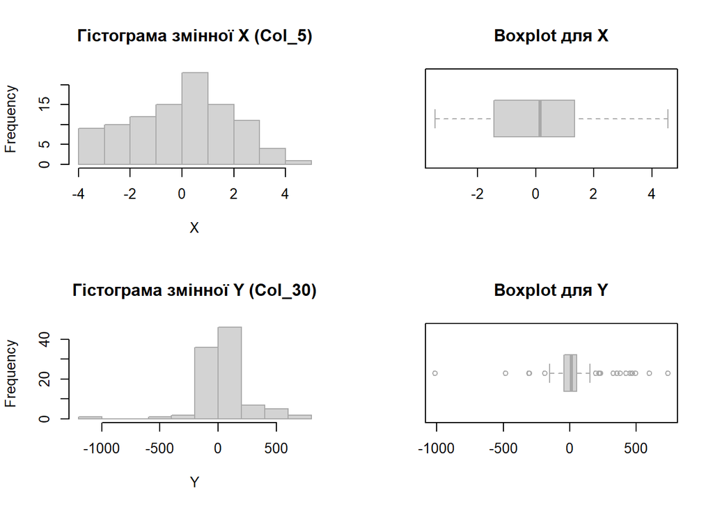

```r
par(mfrow = c(2, 2))

hist(X,
     main = "Гістограма змінної X (Col_5)",
     xlab = "X",
     col  = "lightgray",
     border = "darkgray")

boxplot(X,
        main = "Boxplot для X",
        horizontal = TRUE,
        col = "lightgray",
        border = "darkgray")

hist(Y,
     main = "Гістограма змінної Y (Col_30)",
     xlab = "Y",
     col  = "lightgray",
     border = "darkgray")

boxplot(Y,
        main = "Boxplot для Y",
        horizontal = TRUE,
        col = "lightgray",
        border = "darkgray")
```

```r
par(mfrow = c(1, 1))
```

> Гістограми демонструють форму розподілу значень змінних $X$ та $Y$  
> (наявність чи відсутність симетрії, можливу асиметрію, “хвости”).  
> Діаграми “ящик з вусами” дозволяють виявити викиди та порівняти положення медіани й квартилів.

### 4. Зв’язок між X та Y (якщо в завданні є кореляція/регресія)

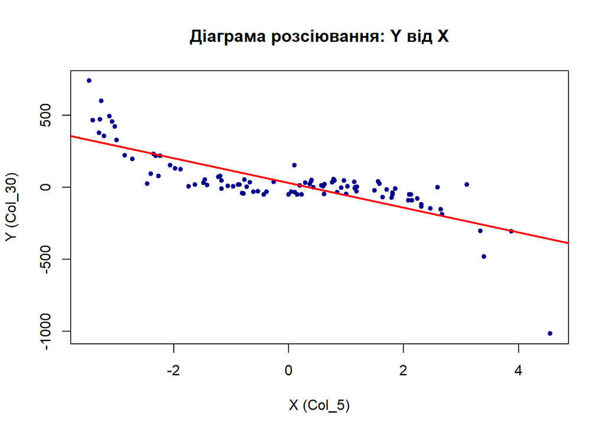

```r
plot(X, Y,
     main = "Діаграма розсіювання: Y від X",
     xlab = "X (Col_5)",
     ylab = "Y (Col_30)",
     pch  = 19,
     cex  = 0.7,
     col  = "darkblue")

model <- lm(Y ~ X)
abline(model, col = "red", lwd = 2)
```

```r
cor_xy <- cor(X, Y, use = "complete.obs", method = "pearson")
cor_xy
```

```
## [1] -0.7888836
```

> На діаграмі розсіювання відображено взаємозв’язок між $X$ та $Y$.  
> Пряма, побудована за моделлю лінійної регресії $Y = \beta_0 + \beta_1 X$,  
> показує загальну тенденцію зміни $Y$ зі зростанням $X$.  
> Коефіцієнт кореляції Пірсона $r$ чисельно характеризує силу та напрямок лінійного зв’язку: $r > 0$ — прямий зв’язок, $r < 0$ — обернений, $|r|$ близько до 0 — слабкий зв’язок.